# Project Corona

# Tasks

- which EU-country has the most cumulative covid-cases and deaths proportional to the number of inhabitants over the entire period of the Covid-pandemic.
- Therefore you need to create a bar chart geom_bar().
  - On the X-axis of the chart, the different EU-countries should be listed (exclude the countries which are not part of the EU!!).
  - The Y-axis should visualize the covid-cases.
- The chart-bars should also include the number of deaths.
  - Due to the high discrepancy between the “cases” and the “deaths”, you should find an adequat method to also visualize the deaths. + group the number of deaths in different categories and to color the boxplot in relation to the respective category (color gradient).
- Take care to show the cases and deaths in relation to the population of the countries, mention this also in the legend.
  - The relation should be in a way, that you divide the total number of daily cases per country with the population number of that country.

## Optional Task

- You can try to find out if there is a relation between the Gross domestic product (GDP) per capita and the total daily covid-cases in this country over the entire period.
  - One possibility to do this could be by testing the correlation between the two variables and later on creating a Scatterplot that shows the distribution and gives us a correlation coefficient.
- More information about how this works can be found on the following website: http://www.sthda.com/english/wiki/correlation-test-between-two-variables-in-r

The dataset can be downloaded as XLS-file from this website: https://de.statista.com/statistik/daten/studie/188766/umfrage/bruttoinlandsprodukt-bip-pro-kopf-in-den-eu-laendern/

Overview about the data structure:

|  | dateRep | day | month | year | cases | deaths | countriesAndTerritories | geoId | countryterritoryCode | popData2020 | continentExp |
| --- | --- | --- | --- | --- | --- | --- | --- | --- | --- | --- | --- |
| 1 | 23/10/2022 | 23 | 10 | 2022 | 3557 | 0 | Austria | AT | AUT | 8901064 | Europe |
| 2 | 22/10/2022 | 22 | 10 | 2022 | 5494 | 4 | Austria | AT | AUT | 8901064 | Europe |
| 3 | 21/10/2022 | 21 | 10 | 2022 | 7776 | 4 | Austria | AT | AUT | 8901064 | Europe |
| 4 | 20/10/2022 | 20 | 10 | 2022 | 8221 | 6 | Austria | AT | AUT | 8901064 | Europe |
| 5 | 19/10/2022 | 19 | 10 | 2022 | 10007 | 8 | Austria | AT | AUT | 8901064 | Europe |
| 6 | 18/10/2022 | 18 | 10 | 2022 | 13204 | 7 | Austria | AT | AUT | 8901064 | Europe |
| 7 | 17/10/2022 | 17 | 10 | 2022 | 9964 | 8 | Austria | AT | AUT | 8901064 | Europe |
| 8 | 16/10/2022 | 16 | 10 | 2022 | 6606 | 12 | Austria | AT | AUT | 8901064 | Europe |
| 9 | 15/10/2022 | 15 | 10 | 2022 | 8818 | 6 | Austria | AT | AUT | 8901064 | Europe |
| 10 | 14/10/2022 | 14 | 10 | 2022 | 11751 | 10 | Austria | AT | AUT | 8901064 | Europe |

Countries and deaths in absolut numbers per year as table and figure:

| countriesAndTerritories | year | sum_year_deaths |
| --- | --- | --- |
| Austria | 2020 | 7535 |
| Austria | 2021 | 9197 |
| Austria | 2022 | 4167 |
| Belgium | 2020 | 19837 |
| Belgium | 2021 | 8563 |
| Belgium | 2022 | 4483 |
| Bulgaria | 2020 | 7515 |
| Bulgaria | 2021 | 23375 |
| Bulgaria | 2022 | 6900 |
| Croatia | 2020 | 3920 |

[output cut: 68 more lines]

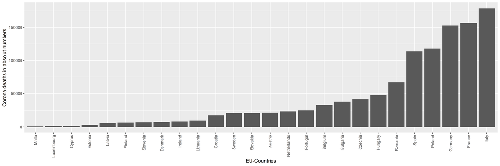

| countriesAndTerritories | year | sum_year_cases | sum_year_deaths | sum_capita_deaths |
| --- | --- | --- | --- | --- |
| Austria | 2020 | 357410 | 7535 | 8.201267e-06 |
| Austria | 2020 | 357410 | 7535 | 8.762997e-06 |
| Austria | 2020 | 357410 | 7535 | 9.324728e-06 |
| Austria | 2020 | 357410 | 7535 | 9.998805e-06 |
| Austria | 2020 | 357410 | 7535 | 7.190152e-06 |
| Austria | 2020 | 357410 | 7535 | 1.056054e-05 |
| Austria | 2020 | 357410 | 7535 | 7.864228e-06 |
| Austria | 2020 | 357410 | 7535 | 9.661766e-06 |
| Austria | 2020 | 357410 | 7535 | 1.112227e-05 |
| Austria | 2020 | 357410 | 7535 | 1.280746e-05 |

[output cut: 9990 more lines]

## Sum of cases

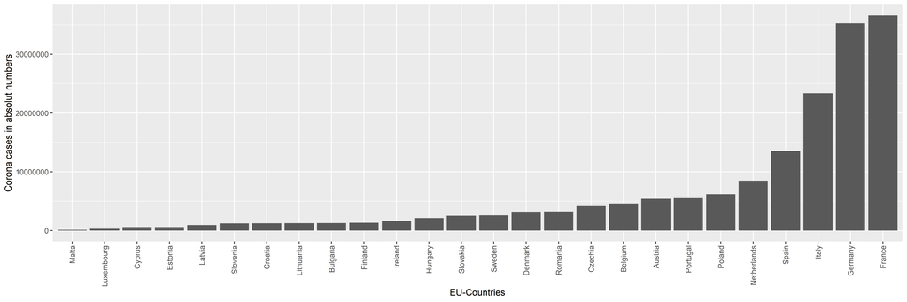

## Sum of cases and mean deaths

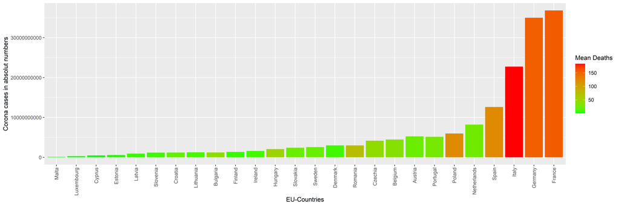

## Sum of cases and mean deaths per capita

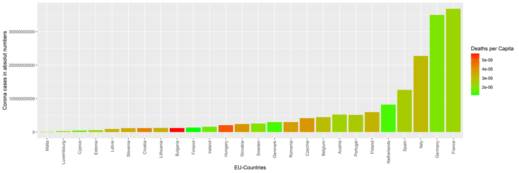

## Corona cases per capita and mean deaths per capita

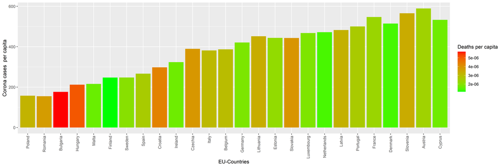